# Effects of Income Ranges and Company Ratings on loans at Prosper

# Investigation Overview

In this investigation, I wanted to focus on the relationships Income Range and the Prosper Rating had with other factors in the dataset, especially the borrower rate

# Dataset Overview

The Data consisted of data of 113,937 loans ranging from 2005-2014 with 81 different variables for each loan. This investigation focused on only 14 of those variables. A high Prosper Rating means an individual is safer or less likely to default on a loan

# Distribution of Income Range

Most of the individuals in the Dataset were located between the income ranges of 25,000 Dollars to 74,999 Dollars. There were a minimal number of people stated as unemployed or earning no income. There were also 7600 people who did not have their income range displayed

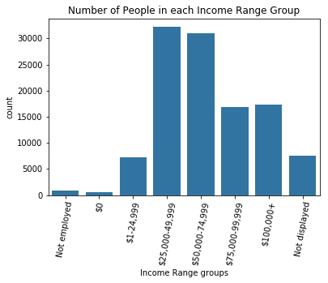

```python
base_color = sb.color_palette()[0]
sb.countplot(data = df2, x = 'IncomeRange', color=base_color);
plt.xticks(rotation=80);
plt.title('Number of People in each Income Range Group')
plt.xlabel('Income Range groups');
```

# Distribution of Borrower Rate and APR

Both the Borrower Rate and the Borrower APR have a similar distribution that range from 0 t0 0.5. This is due to the fact that Borrower APR is basically the Borrower Rate plus a few additional fees from the loan company

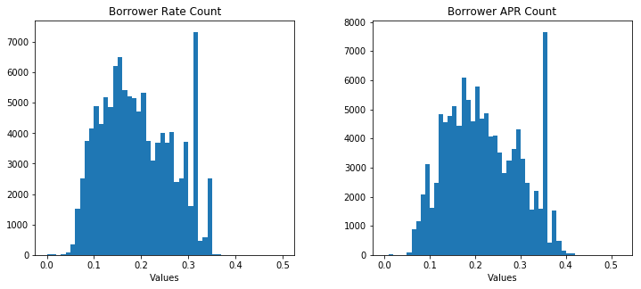

```python
plt.figure(figsize=(12,5))
plt.subplot(1, 2, 1)
bin_edges = np.arange(0, df2.BorrowerRate.max()+0.01, 0.01);
plt.hist(data = df2, x = 'BorrowerRate', bins = bin_edges);
plt.title('Borrower Rate Count')
plt.xlabel('Values')

plt.subplot(1, 2, 2)
bin_edges = np.arange(0, df2.BorrowerAPR.max()+0.01, 0.01);
plt.hist(data = df2, x = 'BorrowerAPR', bins = bin_edges);
plt.xlabel('Values')

plt.subplots_adjust(bottom=0.15, wspace=0.3)
plt.title('Borrower APR Count');
```

# Income Range vs Loan Original Amount

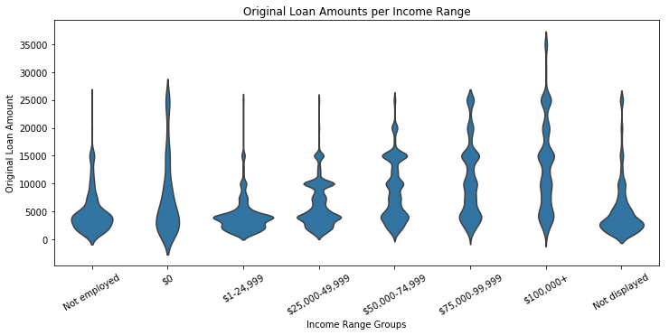

```python
plt.figure(figsize=(12,5))
sb.violinplot(data = df2, x = 'IncomeRange', y = 'LoanOriginalAmount', color=base_color, inner=None);
plt.xticks(rotation=30);
plt.title('Original Loan Amounts per Income Range')
plt.ylabel('Original Loan Amount');
plt.xlabel('Income Range Groups');
```

# Prosper Rating vs Borrower Rate

There is a negative correlation between the Prosper Rating and the Borrower Rate, the higher or less risky the Prosper rating becomes, the lower the average Borrower Rate becomes. This is a very common act for loan companies

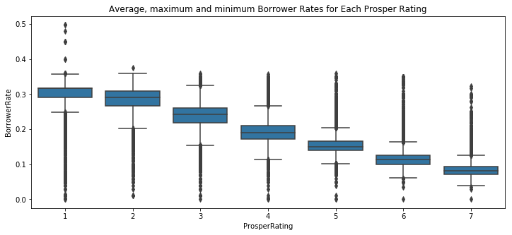

```python
plt.figure(figsize=(12,5));
sb.boxplot(data = df2, x = 'ProsperRating', y = 'BorrowerRate', color=base_color);
plt.xticks();
plt.title('Average, maximum and minimum Borrower Rates for Each Prosper Rating');
```

# Borrower Rate by Year and Income Range

The Average Borrower Rate becomes lower as the income range becomes higher, this also points to the fact that a borrowers Prosper Rating is likely to be higher as their income range increases. There seems to have been a spike in the borrower rates between 2011 and 2012 but the rates have been falling since then in most cases apart from unemplyed or zero income individuals who have experienced a higher spike in their borrower rates.

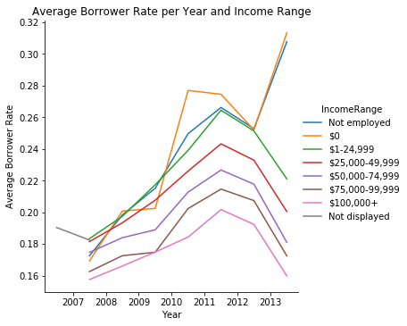

```python
def mean_poly(x, y, bins = 10, **kwargs):
    """ Custom adapted line plot code. """
    # set bin edges if none or int specified
    if type(bins) == int:
        bins = np.linspace(x.min(), x.max(), bins+1)
    bin_centers = (bin_edges[1:] + bin_edges[:-1]) / 2

    # compute counts
    data_bins = pd.cut(x, bins, right = False,
                       include_lowest = True)
    means = y.groupby(data_bins).mean()

    # create plot
    plt.errorbar(x = bin_centers, y = means, **kwargs)

bin_edges = np.arange(2005, 2014+1, 1)
g = sb.FacetGrid(data = df2, hue = 'IncomeRange', height = 5)
g.map(mean_poly, "Year", "BorrowerRate", bins = bin_edges)
g.set_ylabels('mean(BorrowerRate)')
g.add_legend()
plt.title("Average Borrower Rate per Year and Income Range");
plt.ylabel('Average Borrower Rate');
```

# Borrower Rate by Income Range and Home Owner Status

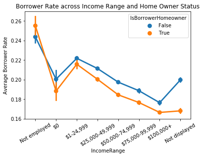

```python
sb.pointplot(data = df2, x = 'IncomeRange', y = 'BorrowerRate', hue = 'IsBorrowerHomeowner');
plt.xticks(rotation=30);
plt.title('Borrower Rate across Income Range and Home Owner Status');
plt.ylabel('Average Borrower Rate');
```